# Clustering and Modeling Lunch and Learn

# Introduction

## What is Clustering?

Clustering is a unsupervised learning method and technique that allows us to group data points close to each other into a single group.

**NOTE :** Unsupervised learning is one of two broad classes of machine learning, in unsupervised learning, there is no outcome variable to predict. Imagine receiving outcomes of a survey, with the survey results we would like to put customers in certain groups. The trouble is we don’t know what these groups are to begin with.

## How can we use clustering?

Clustering can be used in many ways, but the two most common use-cases for clustering are :

1. Simplifying a categorical variable to reduce the number of categories within
2. Cluster a data set entirely

This study will focus on the first application. Regarding the second application, imagine the survey example mentioned above. The goal could be to find groups of people that prefer certain products, without having them buy the products, we can ask them some questions. Based on these answers we can then cluster them into groups of people who would be more likely to buy **product X** or **product Y**. Knowing this information can allow us to market to **group X** differently than to **group Y**.

## Ways to Cluster:

1. K-Means Clustering
2. Hierarchical Clustering
3. Mean-Shift Clustering
4. Density Based Spatial Clustering of Applications with Noise (DBSCAN)
5. Expectation-Maximization (EM) Clustering using Guassian Mixture Models (GMM)

For this tutorial, we will use a public dataset for Income Census Data

1. Clustering  
   The aim of this part is to Cluster a column (country) with 41 modalities (levels) into something more reasonable/simple. This is to reduce number of variables that go into our model because each country can be considered as a separate variable. It can make the model more interpretable if the clusters make sense, i.e. perhapse grouping third-world countries together vs first-world countries.
2. Modeling  
   Build a model on the unclustered data and on the clustered data, and compare models. We will train a binary classification to predict whether someone will have an income higher or lower than 50K.

**Let’s get to it!**

[figure not shown]

# Setup Code and Load Data

## Setting up our environment

First we load all our packages that we need.

```r
# Setup and Load Packages -------------------------------------------------
options(scipen = 999)
if (!is.element("yaml",     .packages(all.available = TRUE))) install.packages("yaml")
if (!is.element("devtools", .packages(all.available = TRUE))) install.packages("devtools")

for (func in list.files(path = "1_code/0_functions/", full.names = TRUE)) source(func)

# Load Meta data
metaData <- yaml::read_yaml(file = "metadata.yaml")

devtools::install_github(repo = metaData$connectionDetails$github$repo, auth_token = metaData$connectionDetails$github$token)
eaR::pkgInstaller(libs = c("tidyverse", "lubridate", "caret", "factoextra", "e1071", "kableExtra"), destinationFolder = "C:/Users/a009831/Documents/rlibraries")
```

## Loading the data

Load the train and test from [here](https://archive.ics.uci.edu/ml/datasets/census+income)

We chose this dataset since it is public, hence a reproducible example. We also need to find a dataset with a categorical variable with a lot of modalities.

I have downloaded this file into my local drive and loaded from my local project.

The data comes in a separate train and test set already but we merged this so that we can choose our own splits.

I fill out the column names because they’re missing in the download.

```r
# Load train and test data ------------------------------------------------
train <- data.table::fread("0_data/Census Income/adult.data.csv") %>%
  eaR::cleanNames(sep = "_")

test <- data.table::fread("0_data/Census Income/adult.test.csv") %>%
  eaR::cleanNames(sep = "_")

# Fill column names
fillColNames <- c("age", "workclass", "fnlwgt", "education", "education_num", "marital_status", "occupation", "relationship", "race", "sex", "capital_gain", "capital_loss", "hours_per_week", "native_country", "income")

base::names(train) <- fillColNames
base::names(test) <- fillColNames

# Join train and test
dat <- train %>%
  dplyr::bind_rows(test)

# Remove df's from memory
rm(test, train)
```

# Structure and cleaning the data

## Inspecting the Data

We then need to clean up the data ready for Clustering and modeling.  
To do this I take a look at the columns that we have, 14 variables plus the Income predictor variable.

```r
dplyr::glimpse(dat)
```

```
Rows: 48,842
Columns: 15
$ age            <int> 39, 50, 38, 53, 28, 37, 49, 52, 31, 42, 37, 30, 23, ...
$ workclass      <chr> "State-gov", "Self-emp-not-inc", "Private", "Private...
$ fnlwgt         <int> 77516, 83311, 215646, 234721, 338409, 284582, 160187...
$ education      <chr> "Bachelors", "Bachelors", "HS-grad", "11th", "Bachel...
$ education_num  <int> 13, 13, 9, 7, 13, 14, 5, 9, 14, 13, 10, 13, 13, 12, ...
$ marital_status <chr> "Never-married", "Married-civ-spouse", "Divorced", "...
$ occupation     <chr> "Adm-clerical", "Exec-managerial", "Handlers-cleaner...
$ relationship   <chr> "Not-in-family", "Husband", "Not-in-family", "Husban...
$ race           <chr> "White", "White", "White", "Black", "Black", "White"...
$ sex            <chr> "Male", "Male", "Male", "Male", "Female", "Female", ...
$ capital_gain   <int> 2174, 0, 0, 0, 0, 0, 0, 0, 14084, 5178, 0, 0, 0, 0, ...
$ capital_loss   <int> 0, 0, 0, 0, 0, 0, 0, 0, 0, 0, 0, 0, 0, 0, 0, 0, 0, 0...
$ hours_per_week <int> 40, 13, 40, 40, 40, 40, 16, 45, 50, 40, 80, 40, 30, ...
$ native_country <chr> "United-States", "United-States", "United-States", "...
$ income         <chr> "<=50K", "<=50K", "<=50K", "<=50K", "<=50K", "<=50K"...
```

### Inspecting the categorical data

I pick out the character columns and inspect the levels of the data.

```r
# Character columns
cols <- c("workclass", "education", "marital_status", "occupation", "relationship", "race", "sex", "native_country", "income")

# Loop through columns and get the unique contents and counts
finRes <- c()
finDf <- base::data.frame()
for (vr in cols) {
  tempresult <- dat %>%
    dplyr::group_by(!!as.name(vr)) %>%
    dplyr::summarise(n = n()) %>%
    dplyr::arrange(-n)
  if(nrow(tempresult) > base::nrow(finDf)) {
    for (ii in 1:(base::nrow(tempresult) - base::nrow(finDf)))  {
      finDf <- finDf %>% dplyr::add_row()
    }
  } else {
    for (ii in 1:(base::nrow(finDf) - base::nrow(tempresult)))  {
      tempresult <- tempresult %>% dplyr::add_row()
    }
  }

  finDf[[vr]] <- tempresult[[vr]]
  finDf[[paste0(vr, "_n")]] <- tempresult$n
}

finDf %>%
  kable() %>%
  kable_styling()
```

| workclass | workclass_n | education | education_n | marital_status | marital_status_n | occupation | occupation_n | relationship | relationship_n | race | race_n | sex | sex_n | native_country | native_country_n | income | income_n |
| --- | --- | --- | --- | --- | --- | --- | --- | --- | --- | --- | --- | --- | --- | --- | --- | --- | --- |
| Private | 33906 | HS-grad | 15784 | Married-civ-spouse | 22379 | Prof-specialty | 6172 | Husband | 19716 | White | 41762 | Male | 32650 | United-States | 43832 | <=50K | 24720 |
| Self-emp-not-inc | 3862 | Some-college | 10878 | Never-married | 16117 | Craft-repair | 6112 | Not-in-family | 12583 | Black | 4685 | Female | 16192 | Mexico | 951 | <=50K. | 12435 |
| Local-gov | 3136 | Bachelors | 8025 | Divorced | 6633 | Exec-managerial | 6086 | Own-child | 7581 | Asian-Pac-Islander | 1519 | NA | NA | ? | 857 | >50K | 7841 |
| ? | 2799 | Masters | 2657 | Separated | 1530 | Adm-clerical | 5611 | Unmarried | 5125 | Amer-Indian-Eskimo | 470 | NA | NA | Philippines | 295 | >50K. | 3846 |
| State-gov | 1981 | Assoc-voc | 2061 | Widowed | 1518 | Sales | 5504 | Wife | 2331 | Other | 406 | NA | NA | Germany | 206 | NA | NA |
| Self-emp-inc | 1695 | 11th | 1812 | Married-spouse-absent | 628 | Other-service | 4923 | Other-relative | 1506 | NA | NA | NA | NA | Puerto-Rico | 184 | NA | NA |
| Federal-gov | 1432 | Assoc-acdm | 1601 | Married-AF-spouse | 37 | Machine-op-inspct | 3022 | NA | NA | NA | NA | NA | NA | Canada | 182 | NA | NA |
| Without-pay | 21 | 10th | 1389 | NA | NA | ? | 2809 | NA | NA | NA | NA | NA | NA | El-Salvador | 155 | NA | NA |
| Never-worked | 10 | 7th-8th | 955 | NA | NA | Transport-moving | 2355 | NA | NA | NA | NA | NA | NA | India | 151 | NA | NA |
| NA | NA | Prof-school | 834 | NA | NA | Handlers-cleaners | 2072 | NA | NA | NA | NA | NA | NA | Cuba | 138 | NA | NA |
| NA | NA | 9th | 756 | NA | NA | Farming-fishing | 1490 | NA | NA | NA | NA | NA | NA | England | 127 | NA | NA |
| NA | NA | 12th | 657 | NA | NA | Tech-support | 1446 | NA | NA | NA | NA | NA | NA | China | 122 | NA | NA |
| NA | NA | Doctorate | 594 | NA | NA | Protective-serv | 983 | NA | NA | NA | NA | NA | NA | South | 115 | NA | NA |
| NA | NA | 5th-6th | 509 | NA | NA | Priv-house-serv | 242 | NA | NA | NA | NA | NA | NA | Jamaica | 106 | NA | NA |
| NA | NA | 1st-4th | 247 | NA | NA | Armed-Forces | 15 | NA | NA | NA | NA | NA | NA | Italy | 105 | NA | NA |
| NA | NA | Preschool | 83 | NA | NA | NA | NA | NA | NA | NA | NA | NA | NA | Dominican-Republic | 103 | NA | NA |
| NA | NA | NA | NA | NA | NA | NA | NA | NA | NA | NA | NA | NA | NA | Japan | 92 | NA | NA |
| NA | NA | NA | NA | NA | NA | NA | NA | NA | NA | NA | NA | NA | NA | Guatemala | 88 | NA | NA |
| NA | NA | NA | NA | NA | NA | NA | NA | NA | NA | NA | NA | NA | NA | Poland | 87 | NA | NA |
| NA | NA | NA | NA | NA | NA | NA | NA | NA | NA | NA | NA | NA | NA | Vietnam | 86 | NA | NA |
| NA | NA | NA | NA | NA | NA | NA | NA | NA | NA | NA | NA | NA | NA | Columbia | 85 | NA | NA |
| NA | NA | NA | NA | NA | NA | NA | NA | NA | NA | NA | NA | NA | NA | Haiti | 75 | NA | NA |
| NA | NA | NA | NA | NA | NA | NA | NA | NA | NA | NA | NA | NA | NA | Portugal | 67 | NA | NA |
| NA | NA | NA | NA | NA | NA | NA | NA | NA | NA | NA | NA | NA | NA | Taiwan | 65 | NA | NA |
| NA | NA | NA | NA | NA | NA | NA | NA | NA | NA | NA | NA | NA | NA | Iran | 59 | NA | NA |
| NA | NA | NA | NA | NA | NA | NA | NA | NA | NA | NA | NA | NA | NA | Greece | 49 | NA | NA |
| NA | NA | NA | NA | NA | NA | NA | NA | NA | NA | NA | NA | NA | NA | Nicaragua | 49 | NA | NA |
| NA | NA | NA | NA | NA | NA | NA | NA | NA | NA | NA | NA | NA | NA | Peru | 46 | NA | NA |
| NA | NA | NA | NA | NA | NA | NA | NA | NA | NA | NA | NA | NA | NA | Ecuador | 45 | NA | NA |
| NA | NA | NA | NA | NA | NA | NA | NA | NA | NA | NA | NA | NA | NA | France | 38 | NA | NA |
| NA | NA | NA | NA | NA | NA | NA | NA | NA | NA | NA | NA | NA | NA | Ireland | 37 | NA | NA |
| NA | NA | NA | NA | NA | NA | NA | NA | NA | NA | NA | NA | NA | NA | Hong | 30 | NA | NA |
| NA | NA | NA | NA | NA | NA | NA | NA | NA | NA | NA | NA | NA | NA | Thailand | 30 | NA | NA |
| NA | NA | NA | NA | NA | NA | NA | NA | NA | NA | NA | NA | NA | NA | Cambodia | 28 | NA | NA |
| NA | NA | NA | NA | NA | NA | NA | NA | NA | NA | NA | NA | NA | NA | Trinadad&Tobago | 27 | NA | NA |
| NA | NA | NA | NA | NA | NA | NA | NA | NA | NA | NA | NA | NA | NA | Laos | 23 | NA | NA |
| NA | NA | NA | NA | NA | NA | NA | NA | NA | NA | NA | NA | NA | NA | Outlying-US(Guam-USVI-etc) | 23 | NA | NA |
| NA | NA | NA | NA | NA | NA | NA | NA | NA | NA | NA | NA | NA | NA | Yugoslavia | 23 | NA | NA |
| NA | NA | NA | NA | NA | NA | NA | NA | NA | NA | NA | NA | NA | NA | Scotland | 21 | NA | NA |
| NA | NA | NA | NA | NA | NA | NA | NA | NA | NA | NA | NA | NA | NA | Honduras | 20 | NA | NA |
| NA | NA | NA | NA | NA | NA | NA | NA | NA | NA | NA | NA | NA | NA | Hungary | 19 | NA | NA |
| NA | NA | NA | NA | NA | NA | NA | NA | NA | NA | NA | NA | NA | NA | Holand-Netherlands | 1 | NA | NA |

## Cleaning the Data

After doing the inspection we can clean up things like “?”’s, names and groupings i.e. native_country = “holand_netherlands”, where there is only one observation.

```r
# Remove finDf since it is no longer needed
rm(finDf)

# Use the above to clean columns
dat <- dat %>%
  dplyr::mutate(workclass      = dplyr::if_else(workclass == "?", "other", workclass) %>% eaR::cleanNames(sep = "_"),
                education      = education %>% eaR::cleanNames(sep = "_"),
                marital_status = marital_status %>% eaR::cleanNames(sep = "_"),
                occupation     = dplyr::if_else(occupation == "?", "other", occupation) %>% eaR::cleanNames(sep = "_"),
                relationship   = relationship %>% eaR::cleanNames(sep = "_"),
                race           = race %>% eaR::cleanNames(sep = "_"),
                sex            = sex %>% eaR::cleanNames(sep = "_"),
                native_country = native_country %>% eaR::cleanNames(sep = "_"),
                native_country = dplyr::if_else(native_country %in% c("", "holand_netherlands"), "other", native_country),
                income         = income %>% gsub(pattern = "\\.", replacement = ""))
```

# Clustering

We will use K-means clustering to define our clusters. Please refer to the appendix for more information on how clustering works.

## Splitting the data

First we use stratified sampling to split our data into 20% for our cluster set and 80 for the rest. We do this to ensure that we do not introduce leakage into our modeling step.

```r
# Stratified sampling separate data into 20 for cluster, 80 train, 20 test
set.seed(123)
splitIndex <- caret::createDataPartition(dat[, native_country],
                                         p     = 0.2,
                                         list  = FALSE,
                                         times = 1)
clusterDF <- dat[splitIndex,  ]
modDF     <- dat[-splitIndex, ]
```

## Creating Clustering Features

Next we need to create some variables to make our cluster for our countries variable that we will cluster

```r
# Clustering Scaling/Standardising of variables/ Mean and Standard deviation to create info
clustPrep <- clusterDF %>%
  dplyr::group_by(native_country) %>%
  dplyr::summarise(meanAge     = age %>% mean(na.rm = TRUE),
                   sdAge       = age %>% sd(na.rm = TRUE),
                   meanEdu     = education_num %>% mean(na.rm = TRUE),
                   sdEdu       = education_num %>% sd(na.rm = TRUE),
                   meanWgt     = fnlwgt %>% mean(na.rm = TRUE),
                   sdWgt       = fnlwgt %>% sd(na.rm = TRUE),
                   meanhours   = hours_per_week %>% mean(na.rm = TRUE),
                   sdhours     = hours_per_week %>% sd(na.rm = TRUE),
                   meanCapGain = capital_gain %>% mean(na.rm = TRUE),
                   sdCapGain   = capital_gain %>% sd(na.rm = TRUE),
                   meanCapLoss = capital_loss %>% mean(na.rm = TRUE),
                   sdCapLoss = capital_loss %>% sd(na.rm = TRUE),
                   sexMale     = sum(sex == "male", na.rm = TRUE),
                   sexAll      = n(),
                   incomeLT50  = sum(income == "<=50K", na.rm = TRUE),
                   incomeAll   = n()) %>%
  dplyr::mutate(incomePropLT50 = incomeLT50 / incomeAll,
                sexMaleProp    = sexMale / sexAll) %>%
  dplyr::select(-c(incomeLT50, incomeAll, sexMale, sexAll)) %>%
  base::as.data.frame()

# Keep a copy of countries to use later, we keep this to later join our clusters back on to it
finClust <- clustPrep %>%
  dplyr::select(native_country)

# Drop categorical variable
rownames(clustPrep) <- clustPrep$native_country
clustPrep$native_country <- NULL
```

Let’s take a quick look at what the clustering data now looks like

```r
clustPrep %>%
  kable() %>%
  kable_styling()
```

|  | meanAge | sdAge | meanEdu | sdEdu | meanWgt | sdWgt | meanhours | sdhours | meanCapGain | sdCapGain | meanCapLoss | sdCapLoss | incomePropLT50 | sexMaleProp |
| --- | --- | --- | --- | --- | --- | --- | --- | --- | --- | --- | --- | --- | --- | --- |
| cambodia | 35.33333 | 11.236844 | 8.166667 | 3.0605010 | 191748.8 | 99109.38 | 40.00000 | 0.000000 | 0.00000 | 0.0000 | 267.00000 | 654.0138 | 0.6666667 | 0.8333333 |
| canada | 48.75676 | 16.233377 | 11.027027 | 3.1665481 | 189618.1 | 107093.68 | 40.54054 | 13.885633 | 4166.70270 | 16746.2103 | 117.67568 | 503.7222 | 0.5405405 | 0.6756757 |
| china | 43.16000 | 10.040252 | 9.680000 | 3.8483763 | 169217.8 | 95967.30 | 39.36000 | 11.600575 | 4615.00000 | 19984.9475 | 0.00000 | 0.0000 | 0.7200000 | 0.7600000 |
| columbia | 31.29412 | 8.651335 | 9.117647 | 2.5952445 | 202018.6 | 55296.27 | 42.05882 | 10.164095 | 0.00000 | 0.0000 | 0.00000 | 0.0000 | 0.9411765 | 0.7647059 |
| cuba | 49.14286 | 12.551270 | 8.892857 | 3.0470300 | 247236.6 | 72100.07 | 41.28571 | 9.486275 | 0.00000 | 0.0000 | 139.39286 | 511.9879 | 0.7500000 | 0.7142857 |
| dominican_republic | 39.95238 | 10.749308 | 7.142857 | 3.9910614 | 188100.6 | 56888.16 | 40.04762 | 4.352886 | 0.00000 | 0.0000 | 0.00000 | 0.0000 | 0.9523810 | 0.5714286 |
| ecuador | 35.66667 | 14.361407 | 9.444444 | 2.6977357 | 190114.9 | 50510.15 | 40.33333 | 16.140012 | 0.00000 | 0.0000 | 0.00000 | 0.0000 | 1.0000000 | 0.5555556 |
| el_salvador | 34.67742 | 13.409914 | 7.258064 | 3.5680783 | 245302.8 | 116423.14 | 35.80645 | 8.893516 | 1241.48387 | 4440.7895 | 0.00000 | 0.0000 | 0.8709677 | 0.6451613 |
| england | 38.23077 | 15.295248 | 10.269231 | 3.3052406 | 164727.6 | 79686.82 | 38.57692 | 14.230033 | 289.80769 | 1027.2339 | 77.00000 | 392.6245 | 0.7692308 | 0.7307692 |
| france | 39.87500 | 13.558735 | 12.250000 | 2.4348658 | 168554.9 | 161093.57 | 47.00000 | 22.097188 | 0.00000 | 0.0000 | 0.00000 | 0.0000 | 0.6250000 | 0.5000000 |
| germany | 39.54762 | 13.440388 | 11.285714 | 2.2007284 | 179250.0 | 96623.84 | 41.14286 | 9.277750 | 1504.90476 | 5335.6902 | 120.14286 | 452.7230 | 0.7380952 | 0.6190476 |
| greece | 50.10000 | 13.584714 | 9.300000 | 4.1646662 | 134951.1 | 30868.70 | 40.90000 | 26.797388 | 438.60000 | 1386.9750 | 406.30000 | 875.4257 | 0.6000000 | 0.9000000 |
| guatemala | 31.88889 | 9.125845 | 8.111111 | 2.6096853 | 255205.4 | 138133.72 | 40.22222 | 9.698730 | 0.00000 | 0.0000 | 0.00000 | 0.0000 | 0.9444444 | 0.7222222 |
| haiti | 41.26667 | 9.617444 | 9.000000 | 3.2071349 | 198735.3 | 70337.70 | 37.66667 | 10.061714 | 0.00000 | 0.0000 | 99.00000 | 383.4254 | 0.8666667 | 0.4666667 |
| honduras | 30.50000 | 6.557438 | 8.500000 | 4.1231056 | 223357.2 | 62229.47 | 29.25000 | 12.473305 | 0.00000 | 0.0000 | 0.00000 | 0.0000 | 0.7500000 | 0.2500000 |
| hong | 33.83333 | 6.369197 | 11.833333 | 4.0702170 | 248956.3 | 88839.48 | 40.00000 | 3.162278 | 2504.00000 | 6133.5223 | 329.50000 | 807.1069 | 0.5000000 | 0.6666667 |
| hungary | 40.25000 | 16.378339 | 12.000000 | 2.0000000 | 154996.8 | 46395.94 | 37.50000 | 20.615528 | 0.00000 | 0.0000 | 0.00000 | 0.0000 | 0.7500000 | 0.5000000 |
| india | 36.70968 | 12.455771 | 12.838710 | 2.0181968 | 174012.1 | 100905.60 | 39.00000 | 11.593101 | 564.09677 | 2719.8198 | 186.77419 | 588.6811 | 0.6451613 | 0.8709677 |
| iran | 33.83333 | 10.267631 | 11.666667 | 1.8257419 | 203621.2 | 103280.84 | 47.58333 | 12.295293 | 0.00000 | 0.0000 | 324.08333 | 757.2926 | 0.6666667 | 0.5833333 |
| ireland | 42.00000 | 10.941402 | 10.000000 | 1.8516402 | 134722.2 | 37972.66 | 39.37500 | 8.210403 | 0.00000 | 0.0000 | 235.87500 | 667.1552 | 0.6250000 | 0.3750000 |
| italy | 45.61905 | 12.188011 | 7.619048 | 3.3087186 | 197933.2 | 71314.53 | 35.09524 | 11.013196 | 193.52381 | 886.8375 | 0.00000 | 0.0000 | 0.8095238 | 0.7142857 |
| jamaica | 36.27273 | 9.735462 | 10.409091 | 2.2606171 | 202241.1 | 62341.11 | 44.09091 | 14.259196 | 0.00000 | 0.0000 | 85.77273 | 402.3098 | 0.9545455 | 0.5454545 |
| japan | 36.00000 | 9.439868 | 11.210526 | 2.0433890 | 258356.5 | 136604.24 | 40.52632 | 11.413289 | 0.00000 | 0.0000 | 83.68421 | 364.7710 | 0.5789474 | 0.4736842 |
| laos | 35.80000 | 8.438009 | 9.400000 | 4.3358967 | 241213.0 | 112684.66 | 40.00000 | 0.000000 | 0.00000 | 0.0000 | 0.00000 | 0.0000 | 0.8000000 | 1.0000000 |
| mexico | 33.00524 | 10.978207 | 6.225131 | 3.4863036 | 279221.0 | 101902.99 | 40.21466 | 9.153141 | 88.62304 | 613.4062 | 31.01571 | 252.4953 | 0.9581152 | 0.7801047 |
| nicaragua | 42.40000 | 17.658489 | 7.000000 | 3.3665016 | 336238.7 | 148415.41 | 33.50000 | 10.926522 | 0.00000 | 0.0000 | 184.80000 | 584.3889 | 0.9000000 | 0.8000000 |
| other | 38.14535 | 11.451746 | 10.668605 | 3.2009780 | 192488.0 | 101301.26 | 41.51744 | 12.795501 | 1327.05233 | 8237.2031 | 90.76163 | 416.5920 | 0.7441860 | 0.6860465 |
| outlying_us_guam_usvi_etc | 30.80000 | 9.497368 | 10.400000 | 1.5165751 | 170553.6 | 76642.05 | 47.00000 | 10.368221 | 0.00000 | 0.0000 | 0.00000 | 0.0000 | 1.0000000 | 0.6000000 |
| peru | 34.60000 | 11.692353 | 9.300000 | 2.2135944 | 321350.6 | 117760.79 | 41.40000 | 9.045564 | 0.00000 | 0.0000 | 0.00000 | 0.0000 | 0.8000000 | 0.6000000 |
| philippines | 38.49153 | 12.759544 | 10.423729 | 3.1469930 | 156184.6 | 89287.32 | 39.72881 | 11.714757 | 1747.49153 | 13018.0635 | 38.27119 | 293.9666 | 0.7457627 | 0.5762712 |
| poland | 44.83333 | 13.025992 | 10.388889 | 2.2528123 | 168694.6 | 34169.00 | 41.55556 | 12.439133 | 547.88889 | 1853.9043 | 108.00000 | 458.2052 | 0.8888889 | 0.6666667 |
| portugal | 40.57143 | 9.171144 | 7.785714 | 2.5169753 | 135478.4 | 72363.21 | 42.92857 | 6.018744 | 0.00000 | 0.0000 | 0.00000 | 0.0000 | 0.7857143 | 0.7857143 |
| puerto_rico | 37.45946 | 13.949501 | 8.297297 | 2.8661324 | 192640.9 | 62103.39 | 41.18919 | 11.189871 | 406.05405 | 2469.9304 | 46.51351 | 282.9307 | 0.9729730 | 0.7027027 |
| scotland | 46.40000 | 11.781341 | 9.400000 | 0.5477226 | 184372.4 | 118484.56 | 39.00000 | 2.236068 | 0.00000 | 0.0000 | 0.00000 | 0.0000 | 0.8000000 | 0.2000000 |
| south | 40.91304 | 15.468187 | 10.434783 | 2.8256309 | 177266.9 | 98909.90 | 45.17391 | 16.084018 | 196.00000 | 939.9830 | 82.04348 | 393.4667 | 0.8695652 | 0.7391304 |
| taiwan | 35.23077 | 9.782244 | 13.461538 | 2.1061570 | 166492.2 | 60433.03 | 43.38462 | 15.478687 | 169.38462 | 610.7249 | 0.00000 | 0.0000 | 0.4615385 | 0.6923077 |
| thailand | 41.66667 | 14.962174 | 11.833333 | 2.1369761 | 128222.7 | 60542.18 | 35.33333 | 13.063945 | 0.00000 | 0.0000 | 0.00000 | 0.0000 | 1.0000000 | 0.5000000 |
| trinadad_tobago | 42.83333 | 13.847984 | 8.833333 | 0.9831921 | 252680.3 | 201586.23 | 41.00000 | 14.628739 | 0.00000 | 0.0000 | 314.50000 | 770.3645 | 0.8333333 | 0.5000000 |
| united_states | 38.62587 | 13.780361 | 10.163340 | 2.4046047 | 187122.1 | 105297.49 | 40.59758 | 12.531203 | 1122.57979 | 7701.8834 | 89.35394 | 406.8905 | 0.7549903 | 0.6673891 |
| vietnam | 27.94444 | 7.392144 | 10.000000 | 2.8901455 | 183940.3 | 88913.91 | 33.38889 | 11.897300 | 379.11111 | 1182.2641 | 184.44444 | 537.5307 | 0.9444444 | 0.6666667 |
| yugoslavia | 36.20000 | 13.809417 | 10.400000 | 1.6733201 | 216934.4 | 84370.95 | 51.00000 | 7.211103 | 0.00000 | 0.0000 | 0.00000 | 0.0000 | 0.6000000 | 1.0000000 |

We could extent this by including other features as well, such as the proportions based on **marital_status**. However it would require a bit of work to create all the extra features. We can also include other statistics such as the inter-quartile ranges.

## Selecting the number of clusters

To select our optimal K (clusters) we will use the elbow method, however there are multiple methods to do this, refer to the appendix for a few more plots and a link to more information.

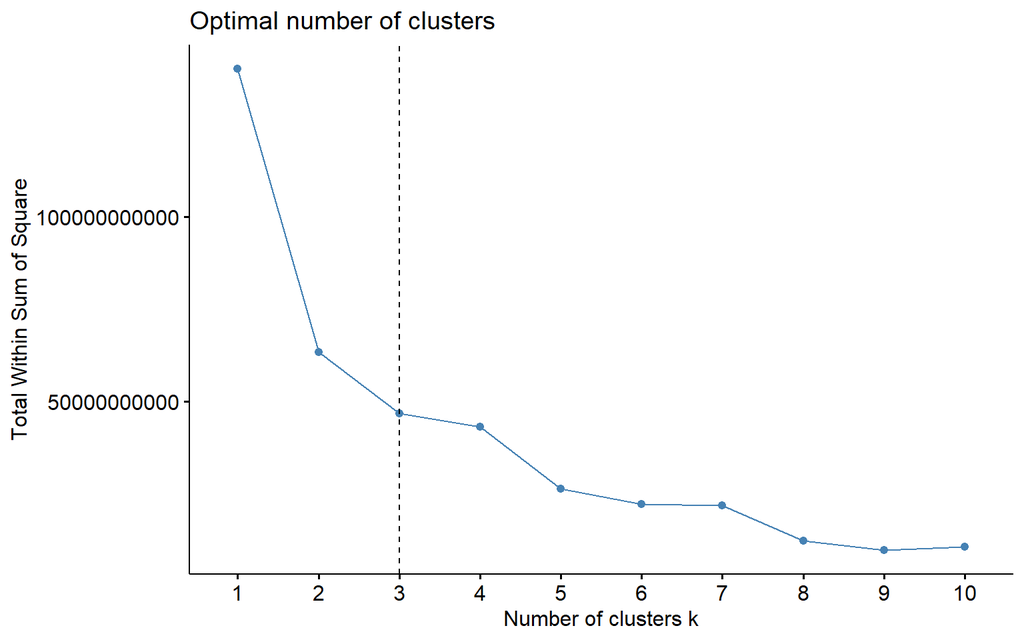

```r
set.seed(123)
factoextra::fviz_nbclust(clustPrep, kmeans, method = "wss") +
  geom_vline(xintercept = 3, linetype = 2)
```

I choose 8 clusters due to the output of the countries clusters making more sense than 3 clusters which the elbow originally suggests. You can test more or less clusters and see how our final model performs as well.  
Here you can see the output of the kmeans function:

```r
# Build clusters with selected k
clusters <- stats::kmeans(clustPrep, centers = 8)

# Look at the output of kmeans
str(clusters)
```

```
List of 9
 $ cluster     : Named int [1:41] 7 7 2 1 8 1 1 4 2 7 ...
  ..- attr(*, "names")= chr [1:41] "cambodia" "canada" "china" "columbia" ...
 $ centers     : num [1:8, 1:14] 38.2 37 42.1 34.3 36.9 ...
  ..- attr(*, "dimnames")=List of 2
  .. ..$ : chr [1:8] "1" "2" "3" "4" ...
  .. ..$ : chr [1:14] "meanAge" "sdAge" "meanEdu" "sdEdu" ...
 $ totss       : num 140012693218
 $ withinss    : num [1:8] 555989238 1478517549 3183370728 1391632132 2766931177 ...
 $ tot.withinss: num 14514215119
 $ betweenss   : num 125498478099
 $ size        : int [1:8] 7 8 7 4 3 2 7 3
 $ iter        : int 3
 $ ifault      : int 0
 - attr(*, "class")= chr "kmeans"
```

We can join our clusters back to the corresponding country data that we reserved earlier on:

```r
# Extract clusters and join back to finClust which holds country data
finClust$cluster <- clusters$cluster

# View of Countries with corresponding cluster
head(finClust)
```

```
      native_country cluster
1           cambodia       7
2             canada       7
3              china       2
4           columbia       1
5               cuba       8
6 dominican_republic       1
```

We can also take a glance some information about each Cluster, the mean Age of each Cluster etc. to give you an idea what each cluster looks like.

```r
# Join back original variables for analysis
clustPrep$clusters <- clusters$cluster
rownames(clustPrep) <- NULL

# Summary analysis
clustPrep %>%
  group_by(clusters) %>%
  summarise_all(.funs = mean) %>%
  kable() %>%
  kable_styling()
```

| clusters | meanAge | sdAge | meanEdu | sdEdu | meanWgt | sdWgt | meanhours | sdhours | meanCapGain | sdCapGain | meanCapLoss | sdCapLoss | incomePropLT50 | sexMaleProp |
| --- | --- | --- | --- | --- | --- | --- | --- | --- | --- | --- | --- | --- | --- | --- |
| 1 | 38.21872 | 11.321781 | 8.718626 | 2.989521 | 195969.2 | 61255.90 | 40.06883 | 11.025853 | 85.65398 | 479.5383 | 33.04089 | 152.6665 | 0.9281809 | 0.6172571 |
| 2 | 36.97463 | 12.043613 | 10.666521 | 2.718986 | 171894.1 | 90867.09 | 40.42142 | 12.095720 | 1162.05148 | 5526.0002 | 86.08452 | 332.3741 | 0.8040325 | 0.6953566 |
| 3 | 42.09317 | 12.549430 | 10.681354 | 2.432747 | 146222.6 | 48963.53 | 40.13958 | 14.660547 | 165.12479 | 550.2292 | 107.16786 | 285.8266 | 0.7301631 | 0.6313841 |
| 4 | 34.32900 | 9.798832 | 8.679132 | 3.865124 | 253673.3 | 104962.57 | 39.00528 | 5.302234 | 958.52673 | 2796.9295 | 90.12893 | 264.9005 | 0.7822707 | 0.7729832 |
| 5 | 36.90741 | 10.804566 | 9.384990 | 1.878756 | 255414.1 | 158774.73 | 40.58285 | 11.913586 | 0.00000 | 0.0000 | 132.72807 | 378.3785 | 0.7855750 | 0.5653021 |
| 6 | 38.50000 | 14.675421 | 8.150000 | 2.790048 | 328794.7 | 133088.10 | 37.45000 | 9.986043 | 0.00000 | 0.0000 | 92.40000 | 292.1945 | 0.8500000 | 0.7000000 |
| 7 | 40.13852 | 12.615719 | 10.477472 | 2.377280 | 188217.9 | 113665.83 | 42.31984 | 10.834412 | 945.19069 | 4669.3281 | 126.98208 | 391.2159 | 0.6854357 | 0.5922540 |
| 8 | 38.61429 | 10.972709 | 9.264286 | 2.947818 | 229176.1 | 72900.16 | 40.51190 | 9.723561 | 0.00000 | 0.0000 | 46.46429 | 170.6626 | 0.7000000 | 0.6547619 |

# Modeling

## Modeling setup

First I join our newly made clusters onto our modeling dataset so we can use it. I also convert the income variable into a factor, giving it a new clean name.

```r
# Join clusters onto Modeling Data
modDF <- modDF %>%
  left_join(finClust, by = c("native_country" = "native_country")) %>%
  mutate(income = ifelse(income == ">50K", "high", "low") %>% as.factor())
```

## Defineing Modelling Framework

I create some key variables, target and our features for our model.

Going forward you will see in the variables we refer to **..Orig** and **..Clust**. **Orig** being our data preclustering, with the full country information and **Clust** being our clustered data.

```r
# Key variables -----------------------------------------------------------
target <- "income"
featOrig  <- c("age", "workclass", "fnlwgt", "education", "education_num", "marital_status",
               "occupation", "relationship", "race", "sex", "capital_gain", "capital_loss",
               "hours_per_week", "native_country")
featClust <- c("age", "workclass", "fnlwgt", "education", "education_num", "marital_status",
               "occupation", "relationship", "race", "sex", "capital_gain", "capital_loss",
               "hours_per_week", "cluster")
```

## Splitting the Data

In the next step we spilt the data into a training and test dataset. We use a 80/20 split.

```r
# Split data into 80 train and 20 test
set.seed(123)
splitIndex <- caret::createDataPartition(modDF[, income],
                                         p     = 0.8,
                                         list  = FALSE,
                                         times = 1)
train <- modDF[splitIndex,  ] %>% as.tibble()
trainTarg <- train[[target]]
train[[target]] <- NULL

test  <- modDF[-splitIndex, ] %>% as.tibble()
testTarg <- test[[target]]
test[[target]] <- NULL
```

## Dummifying

Prepare the data for use in modeling, dummify character variables

```r
# Train -------------------------------------------------------------------
trainOrig  <- train[, c(featOrig)]
trainClust <- train[, c(featClust)]

# Dummify variables for train set
trainOrigDummy <- trainOrig %>% dummyVars(formula = "~.", fullRank = F)
trainOrig      <- predict(trainOrigDummy, trainOrig) %>% as.data.frame()
trainOrig[[target]] <- trainTarg

trainClustDummy <- trainClust %>% dummyVars(formula = "~.", fullRank = F)
trainClust      <- predict(trainClustDummy, trainClust) %>% as.data.frame()
trainClust[[target]] <- trainTarg

# Test --------------------------------------------------------------------
testOrig  <- test[, c(featOrig)]
testClust <- test[, c(featClust)]

# Dummify variables for test set
testOrigDummy                 <- testOrig %>% dummyVars(formula = "~.", fullRank = F)
testOrig                      <- predict(testOrigDummy, testOrig) %>% as.data.frame()
testOrig[[target]]            <- testTarg

testClustDummy                  <- testClust %>% dummyVars(formula = "~.", fullRank = F)
testClust                       <- predict(testClustDummy, testClust) %>% as.data.frame()
testClust[[target]]             <- testTarg
```

## Parameter Tuning

In this section we define global parameters for both the models

```r
# Setting Parameters ------------------------------------------------------
objControl <- trainControl(method = 'cv',
                           number = 3,
                           summaryFunction = twoClassSummary,
                           classProbs = TRUE)
set.seed(123)
gbmGrid <- data.frame(interaction.depth = runif(100, 1 ,   5)    %>% round(0),
                      n.trees           = runif(100, 50,   1000) %>% round(0),
                      n.minobsinnode    = runif(100, 1,    100)  %>% round(0),
                      shrinkage         = runif(100, 0.01, 0.2)  %>% round(4)) %>%
  distinct()
```

## Training The Models

### Original Countries

Build our model using the original dataset with Countries

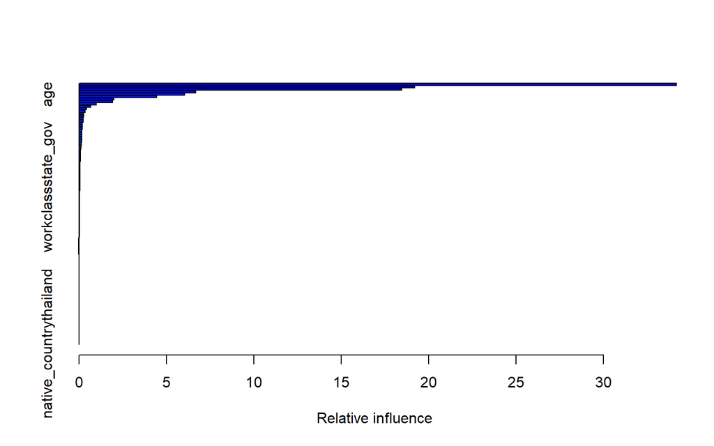

```
                                                              var     rel.inf
marital_statusmarried_civ_spouse marital_statusmarried_civ_spouse 34.16135346
capital_gain                                         capital_gain 19.20552323
education_num                                       education_num 18.45416192
capital_loss                                         capital_loss  6.66847701
age                                                           age  6.03114395
hours_per_week                                     hours_per_week  4.44560141
fnlwgt                                                     fnlwgt  1.98915324
occupationexec_managerial               occupationexec_managerial  1.90791642
occupationprof_specialty                 occupationprof_specialty  0.98613882
relationshipwife                                 relationshipwife  0.68180057
workclassself_emp_not_inc               workclassself_emp_not_inc  0.43773952
occupationother_service                   occupationother_service  0.35619762
occupationsales                                   occupationsales  0.27221095
occupationtech_support                     occupationtech_support  0.26637931
workclassfederal_gov                         workclassfederal_gov  0.25536157
occupationfarming_fishing               occupationfarming_fishing  0.24999818
sexmale                                                   sexmale  0.19118599
workclasslocal_gov                             workclasslocal_gov  0.18774028
occupationprotective_serv               occupationprotective_serv  0.18162010
educationbachelors                             educationbachelors  0.17513021
relationshipnot_in_family               relationshipnot_in_family  0.16708585
racewhite                                               racewhite  0.16095457
workclassself_emp_inc                       workclassself_emp_inc  0.15784371
relationshiphusband                           relationshiphusband  0.15645829
sexfemale                                               sexfemale  0.15171247
native_countryunited_states           native_countryunited_states  0.13447796
occupationadm_clerical                     occupationadm_clerical  0.10704619
marital_statusnever_married           marital_statusnever_married  0.09479522
workclassprivate                                 workclassprivate  0.09370143
occupationhandlers_cleaners           occupationhandlers_cleaners  0.08224026
native_countrycanada                         native_countrycanada  0.07730735
occupationmachine_op_inspct           occupationmachine_op_inspct  0.07331382
marital_statuswidowed                       marital_statuswidowed  0.06357668
native_countryitaly                           native_countryitaly  0.06339191
educationsome_college                       educationsome_college  0.06273104
raceblack                                               raceblack  0.05844600
raceasian_pac_islander                     raceasian_pac_islander  0.05729385
 [ reached 'max' / getOption("max.print") -- omitted 70 rows ]
```

```r
# Build model using countries ---------------------------------------------
formFeats  <- names(trainOrig)[names(trainOrig) != target]
modFormula <- formula(paste0(target, " ~ ", paste0(formFeats, collapse = " + ")))
set.seed(123)
trainOrigObjModel <- caret::train(modFormula,
                                  data         = trainOrig,
                                  distribution = "bernoulli",
                                  method       = "gbm",
                                  metric       = "ROC",
                                  trControl    = objControl,
                                  tuneGrid     = gbmGrid)
# Look at which  variables are important
summary(trainOrigObjModel)
```

```r
# Which tuning parameters were most important
print(trainOrigObjModel)
```

```
Stochastic Gradient Boosting

31247 samples
  107 predictor
    2 classes: 'high', 'low'

No pre-processing
Resampling: Cross-Validated (3 fold)
Summary of sample sizes: 20831, 20831, 20832
Resampling results across tuning parameters:

  shrinkage  interaction.depth  n.minobsinnode  n.trees  ROC        Sens
  0.0116     5                  30              628      0.9188784  0.5993847
  0.0118     4                  96              366      0.9110330  0.5557785
  0.0134     4                  35              260      0.9092771  0.5434724
  0.0164     4                  40              985      0.9215002  0.6221241
  0.0166     3                  56              136      0.9007916  0.5064205
  0.0205     3                  68              950      0.9200260  0.6162386
  0.0280     5                   6              918      0.9245893  0.6384430
  0.0292     1                  11              676      0.9114325  0.5595238
  0.0297     4                   6              401      0.9204292  0.6111557
  0.0300     2                  76              940      0.9188638  0.6110219
  Spec
  0.9483825
  0.9525893
  0.9543562
  0.9452275
  0.9571327
  0.9450171
  0.9442177
  0.9522528
  0.9474150
  0.9450592
 [ reached getOption("max.print") -- omitted 90 rows ]

ROC was used to select the optimal model using the largest value.
The final values used for the model were n.trees = 918, interaction.depth =
 5, shrinkage = 0.028 and n.minobsinnode = 6.
```

Since the data was first split and then dummified, we need to add back some variables to the test set that might have occurred in the training set. Therefore, we nee to add back some missing dummy variables to the test set that were used to build the model.

```r
# Adding missing dummy variables to test set ------------------------------
# Original countries
# Coefficient names used in the model
coefNames <- data.frame(names = trainOrigObjModel$coefnames) %>%
  mutate(n = 1)

testOrigNames <- data.frame(names = names(testOrig)) %>%
  mutate(n = 1)

# Check difference in Model Coefficient names and test dataset
nameDiff <- dplyr::anti_join(coefNames, testOrigNames)

# Add variables that are missing from test
for (nm in nameDiff$names) {
  testOrig[[nm]] <- 0
}
```

### Clustered Countries

Build our model for the dataset with the Clusters

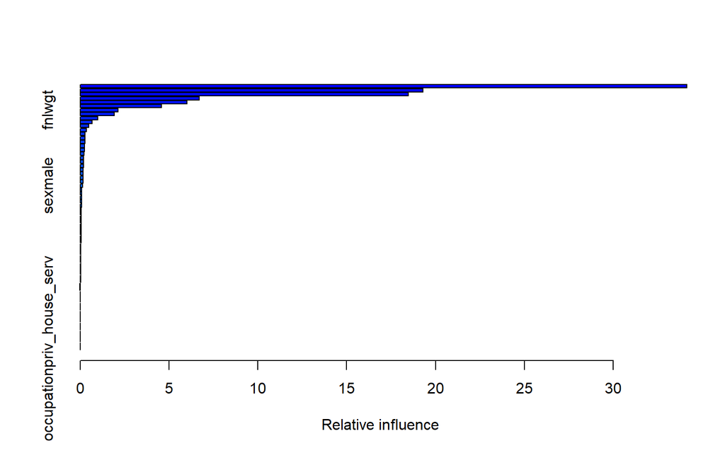

```
                                                              var     rel.inf
marital_statusmarried_civ_spouse marital_statusmarried_civ_spouse 34.14386943
capital_gain                                         capital_gain 19.28350397
education_num                                       education_num 18.46386352
capital_loss                                         capital_loss  6.69790543
age                                                           age  6.00886443
hours_per_week                                     hours_per_week  4.57948258
fnlwgt                                                     fnlwgt  2.13435266
occupationexec_managerial               occupationexec_managerial  1.91368944
occupationprof_specialty                 occupationprof_specialty  0.97579120
relationshipwife                                 relationshipwife  0.68197531
workclassself_emp_not_inc               workclassself_emp_not_inc  0.47497735
occupationother_service                   occupationother_service  0.36278234
occupationtech_support                     occupationtech_support  0.26625847
occupationfarming_fishing               occupationfarming_fishing  0.26575993
occupationsales                                   occupationsales  0.25872567
workclassfederal_gov                         workclassfederal_gov  0.25710659
cluster                                                   cluster  0.24686851
educationbachelors                             educationbachelors  0.21072017
sexfemale                                               sexfemale  0.20332298
workclasslocal_gov                             workclasslocal_gov  0.19546928
relationshipnot_in_family               relationshipnot_in_family  0.19024993
relationshiphusband                           relationshiphusband  0.17126066
workclassself_emp_inc                       workclassself_emp_inc  0.16987011
occupationprotective_serv               occupationprotective_serv  0.16880614
racewhite                                               racewhite  0.16403918
sexmale                                                   sexmale  0.12969370
occupationadm_clerical                     occupationadm_clerical  0.09803062
workclassprivate                                 workclassprivate  0.08943273
occupationhandlers_cleaners           occupationhandlers_cleaners  0.07982659
occupationmachine_op_inspct           occupationmachine_op_inspct  0.07903017
occupationcraft_repair                     occupationcraft_repair  0.07608076
raceasian_pac_islander                     raceasian_pac_islander  0.06810248
marital_statuswidowed                       marital_statuswidowed  0.06023973
marital_statusnever_married           marital_statusnever_married  0.05980623
educationsome_college                       educationsome_college  0.05970615
educationassoc_voc                             educationassoc_voc  0.05949534
educationprof_school                         educationprof_school  0.05773394
 [ reached 'max' / getOption("max.print") -- omitted 30 rows ]
```

```r
# Build model using clusters ----------------------------------------------
formFeats  <- names(trainClust)[names(trainClust) != target]
modFormula <- formula(paste0(target, " ~ ", paste0(formFeats, collapse = " + ")))
set.seed(123)
trainClustObjModel <- caret::train(modFormula,
                                   data         = trainClust,
                                   distribution = "bernoulli",
                                   method       = "gbm",
                                   metric       = "ROC",
                                   trControl    = objControl,
                                   tuneGrid     = gbmGrid)
# Look at which  variables are important
summary(trainClustObjModel)
```

Again, do the same as before but for our clustered dataset

```r
# Adding missing dummy variables to test set ------------------------------
# Clustered countries
# Coefficient names used in the model
coefNames <- data.frame(names = trainClustObjModel$coefnames) %>%
  mutate(n = 1)

testClustNames <- data.frame(names = names(testClust)) %>%
  mutate(n = 1)

# Check difference in Model Coefficient names and test dataset
nameDiff <- dplyr::anti_join(coefNames, testClustNames)

# Add variables that are missing from test
for (nm in nameDiff$names) {
  testClust[[nm]] <- 0
}
```

## Model Evaluation

Model evaluation on both models.

### Original Model on train set

First use the model to predict on the train set, then print some evaluation metrics.

```r
# Model evaluation --------------------------------------------------------
# Original with Countries
# Get predictions and probabilities on your test data
origPredRawtrain  <- predict(object = trainOrigObjModel, trainOrig, type = 'raw')
origPredProbtrain <- predict(object = trainOrigObjModel, trainOrig, type = 'prob')

head(origPredRawtrain)
```

```
[1] low  low  low  low  low  high
Levels: high low
```

```r
head(origPredProbtrain)
```

```
        high        low
1 0.04764373 0.95235627
2 0.03047931 0.96952069
3 0.10288000 0.89712000
4 0.46509916 0.53490084
5 0.49935389 0.50064611
6 0.93056704 0.06943296
```

```r
# Overall Accuracy
print(caret::postResample(pred = origPredRawtrain, obs = as.factor(trainOrig[,"income"])))
```

```
 Accuracy     Kappa
0.8786764 0.6438735
```

```r
aucOrigtrain <- pROC::roc(ifelse(trainOrig[,"income"] == "high", 1, 0), origPredProbtrain[[1]])

print(aucOrigtrain$auc)
```

```
Area under the curve: 0.934
```

### Original Model on test set

Then use the model to predict on the test set and print some evaluation metrics.

```r
# Model evaluation --------------------------------------------------------
# Original with Countries
# Get predictions and probabilities on your test data
origPredRaw  <- predict(object = trainOrigObjModel, testOrig, type = 'raw')
origPredProb <- predict(object = trainOrigObjModel, testOrig, type = 'prob')

head(origPredRaw)
```

```
[1] low low low low low low
Levels: high low
```

```r
head(origPredProb)
```

```
        high       low
1 0.01180675 0.9881933
2 0.18111979 0.8188802
3 0.00883936 0.9911606
4 0.21063047 0.7893695
5 0.06003797 0.9399620
6 0.29277881 0.7072212
```

```r
# Overall Accuracy
print(caret::postResample(pred = origPredRaw, obs = as.factor(testOrig[,"income"])))
```

```
 Accuracy     Kappa
0.8669825 0.6117623
```

```r
aucOrig <- pROC::roc(ifelse(testOrig[,"income"] == "high", 1, 0), origPredProb[[1]])

print(aucOrig$auc)
```

```
Area under the curve: 0.927
```

### Clustered Model on train set

Repeat the same on the Clustered data for train

```r
# Clustered data
# Get predictions and probabilities on your test data
clustPredRawtrain <- predict(object = trainClustObjModel, trainClust, type = 'raw')
clustPredProbtrain <- predict(object = trainClustObjModel, trainClust, type = 'prob')

head(clustPredRawtrain)
```

```
[1] low  low  low  high low  high
Levels: high low
```

```r
head(clustPredProbtrain)
```

```
        high       low
1 0.04116547 0.9588345
2 0.02929703 0.9707030
3 0.10164006 0.8983599
4 0.52784644 0.4721536
5 0.47643135 0.5235686
6 0.93420420 0.0657958
```

```r
# Overall Accuracy
print(caret::postResample(pred = clustPredRawtrain, obs = as.factor(trainClust[,"income"])))
```

```
 Accuracy     Kappa
0.8786443 0.6438668
```

```r
aucClusttrain <- pROC::roc(ifelse(trainClust[,"income"] == "high", 1, 0), clustPredProbtrain[[1]])

print(aucClusttrain$auc)
```

```
Area under the curve: 0.9342
```

### Clustered Model on test set

Repeat the same on the Clustered data for test

```r
# Clustered data
# Get predictions and probabilities on your test data
clustPredRaw <- predict(object = trainClustObjModel, testClust, type = 'raw')
clustPredProb <- predict(object = trainClustObjModel, testClust, type = 'prob')

head(clustPredRaw)
```

```
[1] low low low low low low
Levels: high low
```

```r
head(clustPredProb)
```

```
         high       low
1 0.008639805 0.9913602
2 0.174584832 0.8254152
3 0.008546076 0.9914539
4 0.269156874 0.7308431
5 0.069200820 0.9307992
6 0.289710354 0.7102896
```

```r
# Overall Accuracy
print(caret::postResample(pred = clustPredRaw, obs = as.factor(testClust[,"income"])))
```

```
 Accuracy     Kappa
0.8671105 0.6134165
```

```r
aucClust <- pROC::roc(ifelse(testClust[,"income"] == "high", 1, 0), clustPredProb[[1]])

print(aucClust$auc)
```

```
Area under the curve: 0.9271
```

Here we can see that there isn’t a big difference between the AUC for the test sets. There is a slight improvement although only marginal, ideally we would like to see a bigger improvement but it’s still good because the model with clusters is simpler and countries now has a higher variable importance achieving a similar performance.

# Appendix

## K means Algorithm

With K means Clustering we essentially want to minimize the Intra Cluster distance (Inertia) whilst maximizing the Inter Cluster distance (Dunn Index).

K means finds clusters such that the total intra-cluster variation (or total within-cluster sum of square (WSS)) is minimized. The total WSS measures the compactness of the clustering and we want it to be as small as possible. Refer to appendix to see how to calculate the distance using Euclidian distance.

This gif shows you how K means works: (see the appendix for links to full explanations)

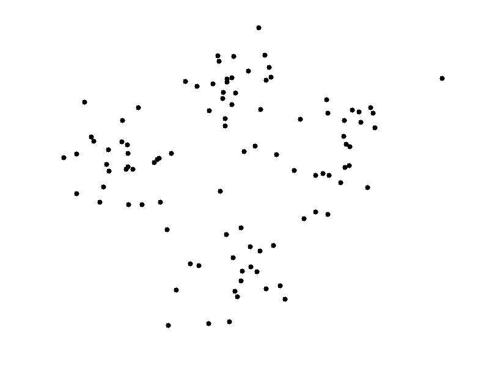

## Euclidean distance

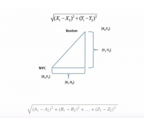

## Other clustering methods and finding K

As mentioned there are other types of clustering and ways to select your optimal K.

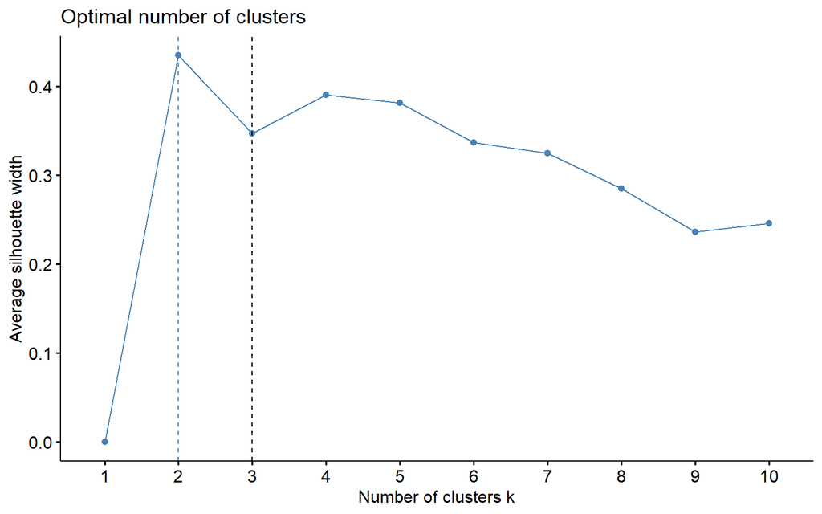

```r
# Hierarchical clustering with Silhouette method
factoextra::fviz_nbclust(clustPrep, cluster::fanny, method = "silhouette") +
  geom_vline(xintercept = 3, linetype = 2)
```

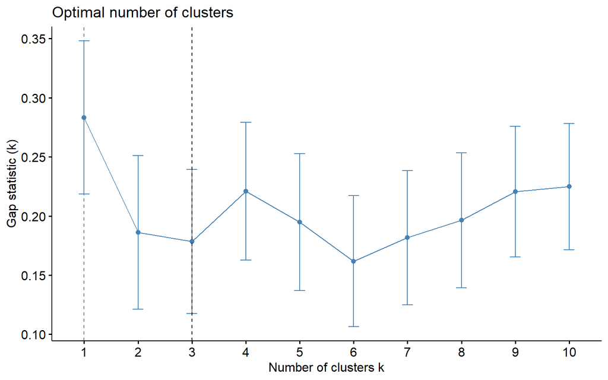

```r
# Hierarchical clustering with Gap statistic
factoextra::fviz_nbclust(clustPrep, hcut, method = "gap_stat") +
  geom_vline(xintercept = 3, linetype = 2)
```

[Link to Cluster Metrics](https://medium.com/@ODSC/unsupervised-learning-evaluating-clusters-bd47eed175ce#:~:text=Within%20Cluster%20Sum%20of%20Squares&text=To%20calculate%20WCSS%2C%20you%20first,by%20the%20number%20of%20points.)

[Link to other types of Clustering Algorithms mentioned at the start](https://towardsdatascience.com/the-5-clustering-algorithms-data-scientists-need-to-know-a36d136ef68)